# RPU 2013 Analyse

```
## 433 2906
```

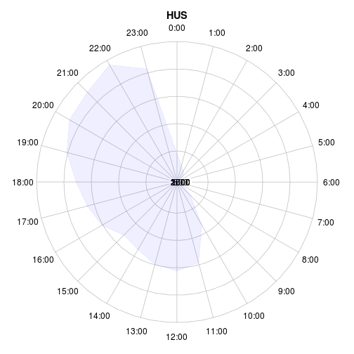

```
## 500 1000 1500 2000 2500 3000
```

```r
clock24.plot(t2, clock.pos = 1:24, rp.type = "p", main = "HUS", xlab = "Heures d'arrivée aux urgences",
    show.grid.labels = F, poly.col = fadeColor("blue", fade = "10"), line.col = fadeColor("blue",
        fade = "10"))
```

Idem pour les sorties

```r
s <- ymd_hms(Hus$SORTIE)
mean(is.na(s))
```

```
## [1] 0.3529
```

```
## 413 1941
```

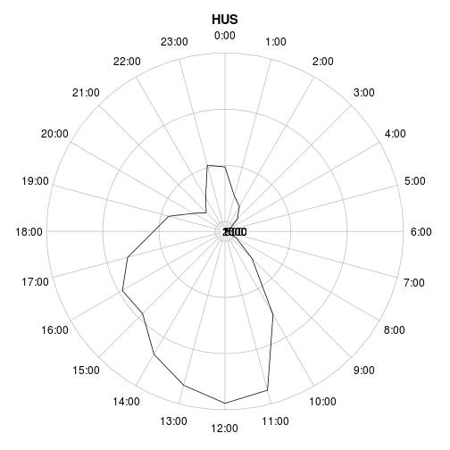

```
## 500 1000 1500 2000
```

```r
t3 <- as.integer(table(hour(s)))
clock24.plot(t3, clock.pos = 1:24, rp.type = "p", main = "HUS", xlab = "Heures de sortie des urgences",
    show.grid.labels = F)
```

Combinaison entrée-sortie

```
## 413 2906
```

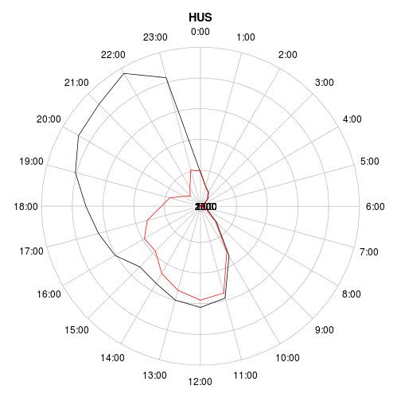

```
## 500 1000 1500 2000 2500 3000
```

```r
t4 <- rbind(t2, t3)
clock24.plot(t4, clock.pos = 1:24, rp.type = "p", main = "HUS", xlab = "Heures d'arrivée aux urgences",
    show.grid.labels = F)
```

```
## 413 2906
```

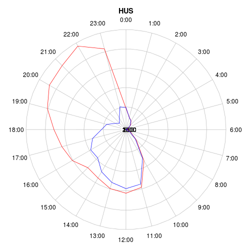

```
## 500 1000 1500 2000 2500 3000
```

```r
clock24.plot(t4, clock.pos = 1:24, rp.type = "p", main = "HUS", xlab = "Heures d'arrivée aux urgences",
    show.grid.labels = F, line.col = c("red", "blue"))
```

```
## 413 2906
```

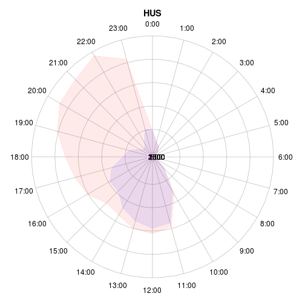

```
## 500 1000 1500 2000 2500 3000
```

```r
fadeBlue <- fadeColor("blue", fade = "15")
fadeRed <- fadeColor("red", fade = "15")
clock24.plot(t4, clock.pos = 1:24, rp.type = "p", main = "HUS", xlab = "Heures d'arrivée aux urgences",
    show.grid.labels = F, line.col = c(fadeRed, fadeBlue), poly.col = c(fadeRed,
        fadeBlue))
```

Entrées selon la période du jour: nuit profonde NP (0h-8h = 1), journée JO (8h-20h = 2), soir SR (20h-24h = 3). La date/heure d'entrée est transformée en heure entière par la fonction *hour*. hest à son tour segmenté en 3 périodes.

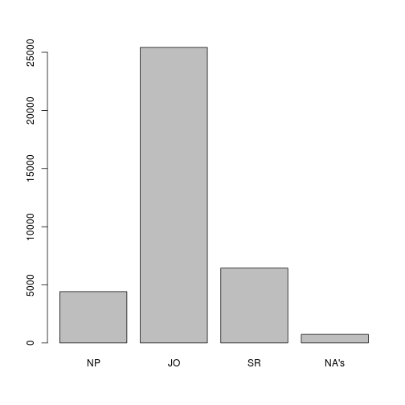

```r
e <- ymd_hms(Hus$ENTREE)
h <- hour(e)
b <- cut(h, c(0, 8, 20, 24), labels = c("NP", "JO", "SR"))
bp <- summary(as.factor(b))
barplot(bp)
```

```r
round(prop.table(bp) * 100, 2)
```

```
##    NP    JO    SR  NA's
## 11.93 68.66 17.40  2.00
```

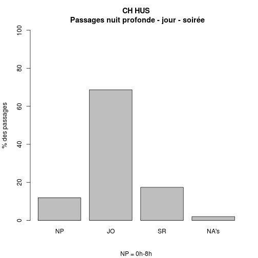

```r
barplot(round(prop.table(bp) * 100, 2), ylab = "% des passages", sub = "NP = 0h-8h",
    ylim = c(0, 100), main = "CH HUS\n Passages nuit profonde - jour - soirée")
```

```r
t <- table(Hus$GRAVITE, b)
t
```

```
##    b
##       NP   JO   SR
##   1  254 1247  195
##   2 1996 6194  695
##   3 1014 3251  300
##   4  118  403   42
##   5   36   77   14
##   D    0    1    0
```

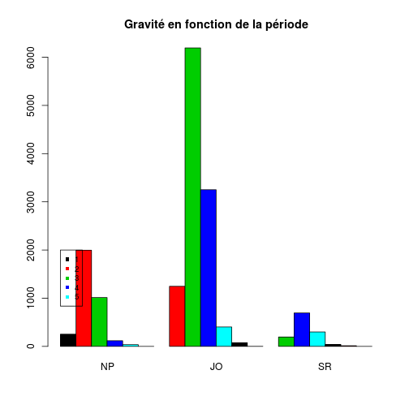

```r
barplot(t, beside = T, col = 1:5, main = "Gravité en fonction de la période")
legend(1, 2000, c(1:5), col = c(1:5), pch = 15, cex = 0.8)
```

Mode sortie en fonction de la période

```r
t <- table(Hus$MODE_SORTIE, b)
t
```

```
##            b
##                NP    JO    SR
##   NA            0     0     0
##   Mutation   4067 14135  1440
##   Transfert     0     0     0
##   Domicile    119   577    80
##   Décès         0     0     0
```

```r
t <- table(Hus$ORIENTATION, b)
```

## Comparaison Mode de sortie - Gravite

```r
a <- table(d1$MODE_SORTIE, d1$GRAVITE)
a
```

```
##
##                  1      2      3      4      5      D      P
##   NA             0      0      0      0      0      0      0
##   Mutation    2305  25213  27333   2778    678     10    444
##   Transfert    140   2503   1594     89     40      0    309
##   Domicile   34308 163928   8216    200     26      4    593
##   Décès          0      2      0      0      0      0      0
```

## Comparaison Orientation - Gravite

```r
a <- table(d1$ORIENTATION, d1$GRAVITE)
a
```

```
##
##             1     2     3     4     5     D     P
##   CHIR    181  3331  3662   363    11     1   140
##   FUGUE    65   139    22     0     0     0     9
##   HDT       4    30    24     1     0     0    48
##   HO        0    16     5     0     0     0    10
##   MED     827  5966  9670   704    39     1   274
##   OBST      3    53    35     3     0     0     0
##   PSA    1057   551    32     0     0     0     8
##   REA       1    99   246   266   408     0     3
##   REO     946   348    52     0     0     0     1
##   SC       80   419   749   138    24     0     9
##   SCAM     74   317    81     3     0     0     2
##   SI       19   319   757   255    29     0     2
##   UHCD   1258 12752  9190  1157   191     7    48
```

```r
xtable(a)
```

```
## % latex table generated in R 3.0.2 by xtable 1.7-1 package
## % Thu Feb 27 18:37:32 2014
## \begin{table}[ht]
## \centering
## \begin{tabular}{rrrrrrrr}
##   \hline
##  & 1 & 2 & 3 & 4 & 5 & D & P \\
##   \hline
## CHIR & 181 & 3331 & 3662 & 363 &  11 &   1 & 140 \\
##   FUGUE &  65 & 139 &  22 &   0 &   0 &   0 &   9 \\
##   HDT &   4 &  30 &  24 &   1 &   0 &   0 &  48 \\
##   HO &   0 &  16 &   5 &   0 &   0 &   0 &  10 \\
##   MED & 827 & 5966 & 9670 & 704 &  39 &   1 & 274 \\
##   OBST &   3 &  53 &  35 &   3 &   0 &   0 &   0 \\
##   PSA & 1057 & 551 &  32 &   0 &   0 &   0 &   8 \\
##   REA &   1 &  99 & 246 & 266 & 408 &   0 &   3 \\
##   REO & 946 & 348 &  52 &   0 &   0 &   0 &   1 \\
##   SC &  80 & 419 & 749 & 138 &  24 &   0 &   9 \\
##   SCAM &  74 & 317 &  81 &   3 &   0 &   0 &   2 \\
##   SI &  19 & 319 & 757 & 255 &  29 &   0 &   2 \\
##   UHCD & 1258 & 12752 & 9190 & 1157 & 191 &   7 &  48 \\
##    \hline
## \end{tabular}
## \end{table}
```

## Age et gravité

On fabrique une nouvelle colonne appelée **cat** qui partage la coleene *age* en 4 catégories. La première categorie comence a -1 pour prendre en compte les moins de 1 an.

```r
d1$cat <- cut(d1$AGE, c(-1, 15, 50, 75, 120), labels = c("Jeunes", "Adultes",
    "Agés", "Très agés"))
table(d1$cat, d1$GRAVITE)
```

```
##
##                 1     2     3     4     5     D     P
##   Jeunes    16748 46938  3757   139    32     1    33
##   Adultes   14480 95252 11048   674   178     2   975
##   Agés       5451 40786 12317  1205   354    11   320
##   Très agés  2051 23451 13295  1543   304    24    52
```

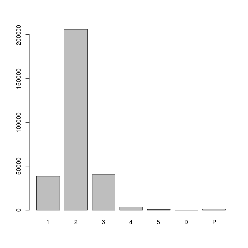

```r
barplot(table(d1$GRAVITE))
```

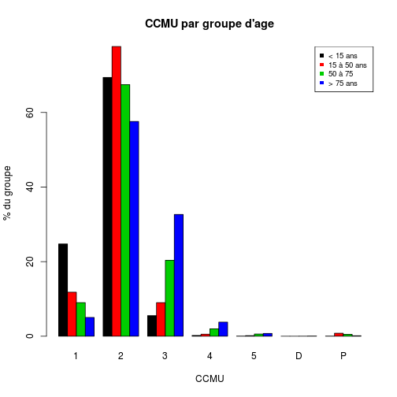

```r
barplot(round(prop.table(table(d1$cat, d1$GRAVITE), margin = 1) * 100, 2), beside = T,
    xlab = "CCMU", ylab = "% du groupe", main = "CCMU par groupe d'age", col = c(1:4))
legend("topright", legend = c("< 15 ans", "15 à 50 ans", "50 à 75", "> 75 ans"),
    cex = 0.8, pch = 15, col = c(1:4))
```

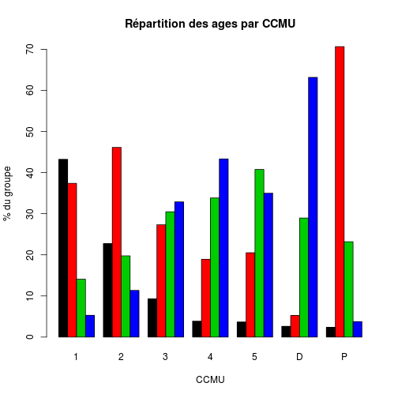

```r
barplot(round(prop.table(table(d1$cat, d1$GRAVITE), margin = 2) * 100, 2), beside = T,
    xlab = "CCMU", ylab = "% du groupe", main = "Répartition des ages par CCMU",
    col = c(1:4))
```

Représentation sous forme de barres emplilées avec légende

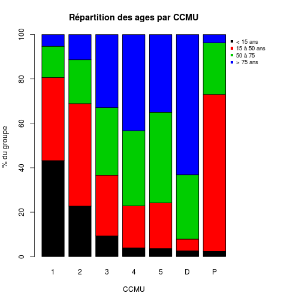

```r
par(mar = c(5, 4, 4, 8))
barplot(round(prop.table(table(d1$cat, d1$GRAVITE), margin = 2) * 100, 2), beside = FALSE,
    xlab = "CCMU", ylab = "% du groupe", main = "Répartition des ages par CCMU",
    col = c(1:4))
par(mar = c(5, 4, 4, 2))
legend(x = 8.5, y = 100, legend = c("< 15 ans", "15 à 50 ans", "50 à 75",
    "> 75 ans"), cex = 0.8, pch = 15, col = c(1:4), bty = "n")
```